# Saas/Ecommerce-cohort-retention & CLTV_Project

## Day 8- PowerBI Preparation And Business Insights

## Objective

Prepare final business insights, KPI framework, dashboard structure, and reporting datasets for the SaaS/E-Commerce Cohort Retention & CLTV Analysis Project.

This notebook focuses on transforming analytical findings into business-ready insights and dashboard requirements for decision-makers.

```python
# Import Required libraries
import pandas as pd
import numpy as np
```

```python
# Load data
file_path = r"C:\Users\LENOVO\Desktop\Saas-Ecommerce-cohort-retention-CLTV_Project\data\processed\customer_cltv_segments.csv"

df = pd.read_csv(file_path)
```

```python
# Basic looks of data
df.shape
```

```
(5878, 6)
```

```python
df.head()
```

|  | Customer ID | Revenue | Total_Orders | AOV | CLTV | CLTV_Segment |
| --- | --- | --- | --- | --- | --- | --- |
| 0 | 12346.0 | 77556.46 | 12 | 6463.038333 | 82187.988338 | A |
| 1 | 12347.0 | 4921.53 | 8 | 615.191250 | 7823.152003 | A |
| 2 | 12348.0 | 2019.40 | 5 | 403.880000 | 5135.987599 | B |
| 3 | 12349.0 | 4428.69 | 4 | 1107.172500 | 14079.489526 | A |
| 4 | 12350.0 | 334.40 | 1 | 334.400000 | 4252.436994 | B |

```python
df.info()
```

```
<class 'pandas.DataFrame'>
RangeIndex: 5878 entries, 0 to 5877
Data columns (total 6 columns):
 #   Column        Non-Null Count  Dtype
---  ------        --------------  -----
 0   Customer ID   5878 non-null   float64
 1   Revenue       5878 non-null   float64
 2   Total_Orders  5878 non-null   int64
 3   AOV           5878 non-null   float64
 4   CLTV          5878 non-null   float64
 5   CLTV_Segment  5878 non-null   str
dtypes: float64(4), int64(1), str(1)
memory usage: 275.7 KB
```

```python
df.isnull().sum()
```

```
Customer ID     0
Revenue         0
Total_Orders    0
AOV             0
CLTV            0
CLTV_Segment    0
dtype: int64
```

```python
df["CLTV_Segment"].value_counts()
```

```
CLTV_Segment
A    1470
D    1470
B    1469
C    1469
Name: count, dtype: int64
```

```python
# Business Insight 1 - Revenue Contribution by Segment

segment_revenue = df.groupby("CLTV_Segment")["Revenue"].sum()

segment_revenue
```

```
CLTV_Segment
A    1.132433e+07
B    3.397292e+06
C    1.883001e+06
D    7.701830e+05
Name: Revenue, dtype: float64
```

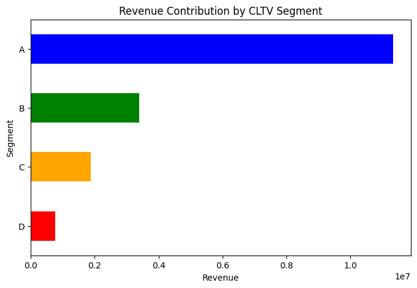

```python
# Visualization - Revenue Contribution by Segment

import matplotlib.pyplot as plt
import seaborn as sns
plt.figure(figsize=(8,5))

segment_revenue.sort_values().plot(
    kind="barh",
    color=["red","orange","green","blue"]
)

plt.title("Revenue Contribution by CLTV Segment")
plt.xlabel("Revenue")
plt.ylabel("Segment")

plt.show()
```

```python
# Business Insight 2 - Customer Distribution by Segment

customer_distribution = df["CLTV_Segment"].value_counts()

customer_distribution
```

```
CLTV_Segment
A    1470
D    1470
B    1469
C    1469
Name: count, dtype: int64
```

```python
customer_distribution.sum()
```

```
np.int64(5878)
```

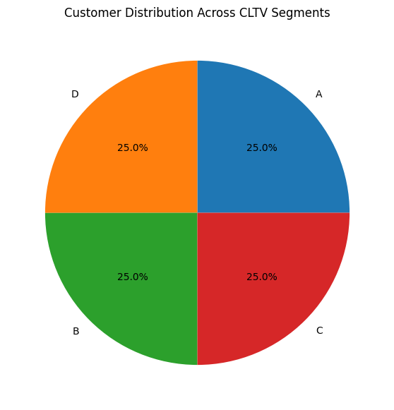

```python
# Visualization - Customer Distribution by Segment

plt.figure(figsize=(7,7))

plt.pie(
    customer_distribution,
    labels=customer_distribution.index,
    autopct="%1.1f%%"
)

plt.title("Customer Distribution Across CLTV Segments")

plt.show()
```

```python
# Business Insight 3 - Average Revenue by Segment

avg_revenue = df.groupby(
    "CLTV_Segment"
)["Revenue"].mean()

avg_revenue
```

```
CLTV_Segment
A    7703.624605
B    2312.656312
C    1281.825048
D     523.934000
Name: Revenue, dtype: float64
```

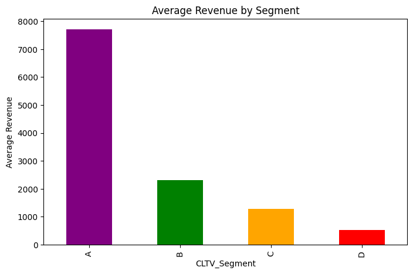

```python
# Visualization - Average Revenue by Segment

plt.figure(figsize=(8,5))

avg_revenue.plot(
    kind="bar",
    color=["purple","green","orange","red"]
)

plt.title("Average Revenue by Segment")
plt.ylabel("Average Revenue")

plt.show()
```

```python
# Business Insight 4 - Average Orders by Segment

avg_orders = df.groupby(
    "CLTV_Segment"
)["Total_Orders"].mean()

avg_orders
```

```
CLTV_Segment
A    8.734014
B    6.802587
C    5.656909
D    3.963946
Name: Total_Orders, dtype: float64
```

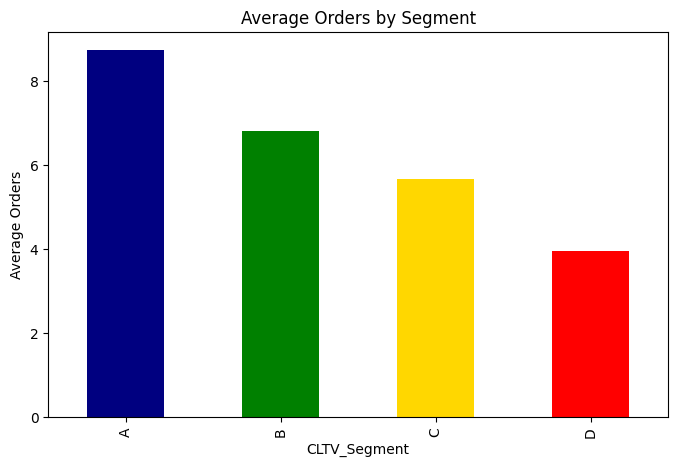

```python
# Visualization - Average Orders by Segment

plt.figure(figsize=(8,5))

avg_orders.plot(
    kind="bar",
    color=["navy","green","gold","red"]
)

plt.title("Average Orders by Segment")
plt.ylabel("Average Orders")

plt.show()
```

```python
# Business Insight 5 - Average CLTV by Segment

avg_cltv = df.groupby(
    "CLTV_Segment"
)["CLTV"].mean()

avg_cltv
```

```
CLTV_Segment
A    10865.444078
B     4309.806744
C     2867.581517
D     1548.176187
Name: CLTV, dtype: float64
```

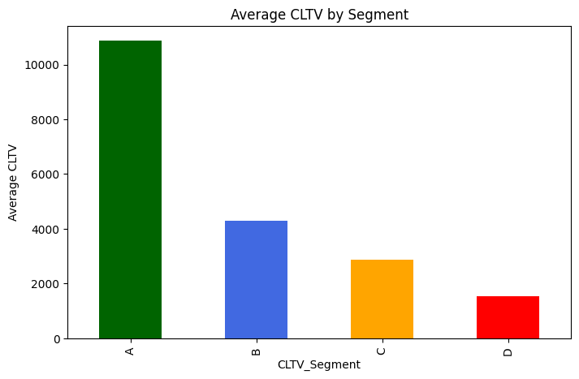

```python
# Visualization - Average CLTV by Segment

plt.figure(figsize=(8,5))

avg_cltv.plot(
    kind="bar",
    color=["darkgreen","royalblue","orange","red"]
)

plt.title("Average CLTV by Segment")
plt.ylabel("Average CLTV")

plt.show()
```

```python
# Compare Revenue and CLTV Together

segment_summary = df.groupby(
    "CLTV_Segment"
).agg(
    Avg_Revenue=("Revenue","mean"),
    Avg_CLTV=("CLTV","mean")
)

segment_summary
```

| CLTV_Segment | Avg_Revenue | Avg_CLTV |
| --- | --- | --- |
| A | 7703.624605 | 10865.444078 |
| B | 2312.656312 | 4309.806744 |
| C | 1281.825048 | 2867.581517 |
| D | 523.934000 | 1548.176187 |

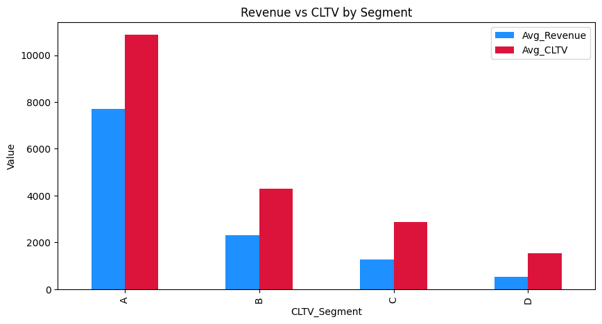

```python
# Visualization - Revenue vs CLTV

segment_summary.plot(
    kind="bar",
    figsize=(10,5),
    color=["dodgerblue","crimson"]
)

plt.title("Revenue vs CLTV by Segment")
plt.ylabel("Value")

plt.show()
```

```python
# Top 10 Customers by CLTV

top_10_cltv = df.sort_values(
    by="CLTV",
    ascending=False
).head(10)

top_10_cltv[
    ["Customer ID","Revenue","Total_Orders","AOV","CLTV"]
]
```

|  | Customer ID | Revenue | Total_Orders | AOV | CLTV |
| --- | --- | --- | --- | --- | --- |
| 4061 | 16446.0 | 168472.50 | 2 | 84236.250000 | 1.071200e+06 |
| 3371 | 15749.0 | 44534.30 | 3 | 14844.766667 | 1.887752e+05 |
| 2722 | 15098.0 | 39916.50 | 3 | 13305.500000 | 1.692010e+05 |
| 1324 | 13687.0 | 11880.84 | 1 | 11880.840000 | 1.510841e+05 |
| 569 | 12918.0 | 10953.50 | 1 | 10953.500000 | 1.392915e+05 |
| 5642 | 18052.0 | 10877.18 | 1 | 10877.180000 | 1.383209e+05 |
| 3382 | 15760.0 | 13916.34 | 2 | 6958.170000 | 8.848439e+04 |
| 1538 | 13902.0 | 34095.26 | 5 | 6819.052000 | 8.671528e+04 |
| 0 | 12346.0 | 77556.46 | 12 | 6463.038333 | 8.218799e+04 |
| 11 | 12357.0 | 18287.66 | 3 | 6095.886667 | 7.751906e+04 |

```python
# CLTV Distribution Statistics

df["CLTV"].describe()
```

```
count    5.878000e+03
mean     4.898198e+03
std      1.544162e+04
min      3.751402e+01
25%      2.246804e+03
50%      3.551022e+03
75%      5.276156e+03
max      1.071200e+06
Name: CLTV, dtype: float64
```

```python
# Top Segment Contribution to Total Revenue

top_segment_revenue = (
    segment_revenue["A"]
    /
    segment_revenue.sum()
) * 100

round(top_segment_revenue,2)
```

```
np.float64(65.18)
```

```python
# Business Finding

print(
    f"Segment A contributes {top_segment_revenue:.2f}% of total revenue."
)
```

```
Segment A contributes 65.18% of total revenue.
```

```python
# Business KPI Summary

kpi_summary = pd.DataFrame({
    "Metric":[
        "Total Customers",
        "Total Revenue",
        "Average Revenue",
        "Average CLTV",
        "Top Segment"
    ],
    "Value":[
        len(df),
        round(df["Revenue"].sum(),2),
        round(df["Revenue"].mean(),2),
        round(df["CLTV"].mean(),2),
        "A"
    ]
})

kpi_summary
```

|  | Metric | Value |
| --- | --- | --- |
| 0 | Total Customers | 5878 |
| 1 | Total Revenue | 17374804.27 |
| 2 | Average Revenue | 2955.9 |
| 3 | Average CLTV | 4898.2 |
| 4 | Top Segment | A |

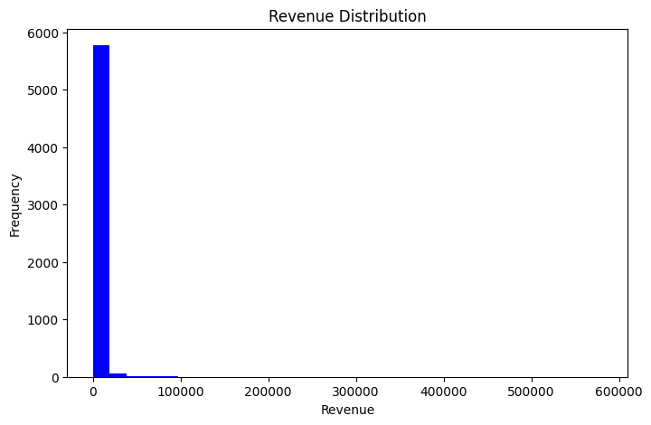

```python
# Visualization - Revenue Distribution

plt.figure(figsize=(8,5))

plt.hist(
    df["Revenue"],
    bins=30,
    color="blue"
)

plt.title("Revenue Distribution")
plt.xlabel("Revenue")
plt.ylabel("Frequency")

plt.show()
```

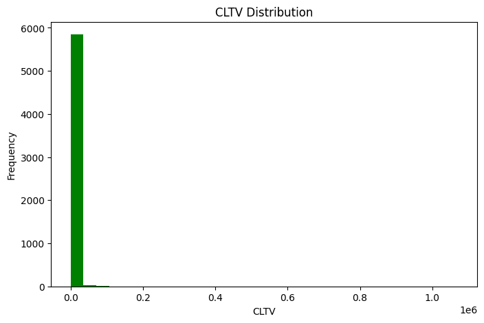

```python
# Visualization - CLTV Distribution

plt.figure(figsize=(8,5))

plt.hist(
    df["CLTV"],
    bins=30,
    color="green"
)

plt.title("CLTV Distribution")
plt.xlabel("CLTV")
plt.ylabel("Frequency")

plt.show()
```

```python
# Top 5 Revenue Generating Customers

top_revenue_customers = df.sort_values(
    by="Revenue",
    ascending=False
).head(5)

top_revenue_customers[
    ["Customer ID","Revenue","CLTV"]
]
```

|  | Customer ID | Revenue | CLTV |
| --- | --- | --- | --- |
| 5692 | 18102.0 | 580987.04 | 50953.035426 |
| 2277 | 14646.0 | 528602.52 | 44516.796140 |
| 1789 | 14156.0 | 313437.62 | 25550.425762 |
| 2538 | 14911.0 | 291420.81 | 9311.274022 |
| 5050 | 17450.0 | 244784.25 | 61035.838269 |

```python
# Segment Wise Revenue Percentage

segment_revenue_pct = round(
    (segment_revenue / segment_revenue.sum()) * 100,
    2
)

segment_revenue_pct
```

```
CLTV_Segment
A    65.18
B    19.55
C    10.84
D     4.43
Name: Revenue, dtype: float64
```

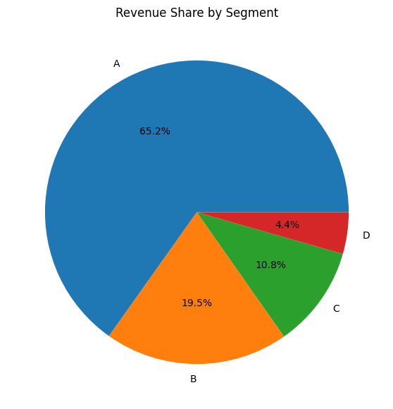

```python
# Visualization - Revenue Share

plt.figure(figsize=(7,7))

plt.pie(
    segment_revenue_pct,
    labels=segment_revenue_pct.index,
    autopct="%1.1f%%"
)

plt.title("Revenue Share by Segment")

plt.show()
```

```python
# Strategic Recommendations

recommendations = pd.DataFrame({
    "Recommendation":[
        "Retain Segment A Customers",
        "Upsell Segment B Customers",
        "Engage Segment C Customers",
        "Reactivate Segment D Customers"
    ]
})

recommendations
```

|  | Recommendation |
| --- | --- |
| 0 | Retain Segment A Customers |
| 1 | Upsell Segment B Customers |
| 2 | Engage Segment C Customers |
| 3 | Reactivate Segment D Customers |

```python
# Notebook Completion Check

print("Business Insights Analysis Completed Successfully")
```

```
Business Insights Analysis Completed Successfully
```

```python
# Create Executive Summary DataFrame
# Create Executive Summary Table

summary_df = pd.DataFrame({
    "Metric": [
        "Total Customers",
        "Total Revenue",
        "Average Revenue",
        "Average CLTV",
        "Top Segment"
    ],
    "Value": [
        len(df),
        round(df["Revenue"].sum(), 2),
        round(df["Revenue"].mean(), 2),
        round(df["CLTV"].mean(), 2),
        df.groupby("CLTV_Segment")["Revenue"].sum().idxmax()
    ]
})

summary_df
```

|  | Metric | Value |
| --- | --- | --- |
| 0 | Total Customers | 5878 |
| 1 | Total Revenue | 17374804.27 |
| 2 | Average Revenue | 2955.9 |
| 3 | Average CLTV | 4898.2 |
| 4 | Top Segment | A |

```python
# Save Executive Summary

summary_df.to_csv(
    r"C:\Users\LENOVO\Desktop\Saas-Ecommerce-cohort-retention-CLTV_Project\data\processed\executive_summary.csv",
    index=False
)

print("Executive Summary Saved Successfully")
```

```
Executive Summary Saved Successfully
```

```python
# Create Business Recommendations

recommendations_df = pd.DataFrame({
    "Recommendation": [
        "Retain Segment A Customers",
        "Upsell Segment B Customers",
        "Engage Segment C Customers",
        "Reactivate Segment D Customers"
    ]
})

recommendations_df
```

|  | Recommendation |
| --- | --- |
| 0 | Retain Segment A Customers |
| 1 | Upsell Segment B Customers |
| 2 | Engage Segment C Customers |
| 3 | Reactivate Segment D Customers |

```python
# Save Business Recommendations

recommendations_df.to_csv(
    r"C:\Users\LENOVO\Desktop\Saas-Ecommerce-cohort-retention-CLTV_Project\data\processed\business_recommendations.csv",
    index=False
)

print("Business Recommendations Saved Successfully")
```

```
Business Recommendations Saved Successfully
```

```python
import os

folder_path = r"C:\Users\LENOVO\Desktop\Saas-Ecommerce-cohort-retention-CLTV_Project\data\processed"

for file in os.listdir(folder_path):
    print(file)
```

```
business_recommendations.csv
cltv_base_data.csv
cohort_prepared_data.csv
customer_cltv_segments.csv
executive_summary.csv
pareto_analysis.csv
retention_base_table.csv
retention_count_matrix.csv
retention_percentage_matrix.csv
segment_summary.csv
```

# Customer Segmentation Analysis & Business Insights

## Objective

The objective of this notebook is to analyze Customer Lifetime Value (CLTV) segments, evaluate customer contribution to revenue, identify high-value customers, perform Pareto Analysis, and generate business recommendations for customer retention and growth strategies.

## Dataset Used

**File:** customer_cltv_segments.csv

This dataset contains:

- Customer ID
- Revenue
- Total Orders
- Average Order Value (AOV)
- Customer Lifetime Value (CLTV)
- CLTV Segment

## Step 1: Load Customer CLTV Dataset

- Imported required libraries
- Loaded customer_cltv_segments.csv
- Verified dataset shape, columns, data types, and missing values

### Validation Checks

- Dataset loaded successfully
- No missing values detected
- Customer count verified

## Step 2: Segment Performance Analysis

Analyzed CLTV segments:

- Segment A
- Segment B
- Segment C
- Segment D

### Key Observation

Segment A customers generated the highest revenue and CLTV values.

## Step 3: Revenue Contribution Analysis

Calculated:

- Total Revenue by Segment
- Revenue Contribution Percentage

### Findings

| Segment | Revenue Contribution |
| --- | --- |
| A | 65.18% |
| B | 19.55% |
| C | 10.84% |
| D | 4.43% |

Segment A contributes the majority of business revenue.

## Step 4: CLTV Contribution Analysis

### Finding

Segment A customers have significantly higher lifetime value compared to other segments.

Calculated:

- Cumulative Revenue
- Cumulative Revenue Percentage

## Step 6: Top Customers Identification

Identified top customers based on:

- Revenue
- CLTV

Generated Top 10 customer list for business targeting.

## Step 7: Executive Summary

Created management-level KPI summary including:

- Total Customers
- Total Revenue
- Average Revenue
- Average CLTV
- Top Performing Segment

## Step 8: Business Recommendations

Generated segment-wise recommendations:

### Segment A

Retain and reward high-value customers.

### Segment B

Upsell and cross-sell premium products.

### Segment C

Increase engagement through campaigns.

### Segment D

Run reactivation and retention campaigns.

## Step 9: Data Export

Exported final dashboard-ready datasets:

- executive_summary.csv
- business_recommendations.csv

These files will be used in the Power BI dashboard phase.